# What this notebook does

### Title: LLM-scCurator Docker Quickstart (Python, Ollama)

This notebook is a minimal end-to-end demo of LLM-scCurator in a local Docker environment using Jupyter and an optional local LLM backend via Ollama.

Using the public PBMC3k (Scanpy) dataset, we:

1. Load and QC cells, normalize/log-transform the data, and run clustering in Python (Scanpy).
2. Generate cluster markers (DE genes) and apply LLM-scCurator’s noise masking / feature distillation.
3. Optionally annotate clusters using a local LLM served by Ollama (no cloud API required).

Core requirement:

- LLM-scCurator expects log1p-normalized expression in `adata.X`.
- Keep raw counts in `adata.layers["counts"]`.

## Environment and prerequisites (Docker + Jupyter + Ollama)

### This notebook is designed to run inside the official Docker environment launched via Docker Compose.

1. Start services (from repo root)

   ```
   # 1. Clone the repository
   git clone https://github.com/kenflab/LLM-scCurator.git
   cd LLM-scCurator

   # 2. Start two services using compose.
   docker compose -f docker/docker-compose.yml up -d

   # 3. Pull the Ollama model once (optional, for local LLM annotation)
   docker compose -f docker/docker-compose.yml exec ollama ollama pull llama3.1:8b
   ```

   Local LLM selection (optional) The Ollama backend is configured via environment variables in `docker/docker-compose.yml`:
   - `LLMSC_OLLAMA_HOST` (default: http://ollama:11434)
   - `LLMSC_OLLAMA_MODEL` (default: llama3.1:8b)

   If you prefer a cloud LLM instead, set `GEMINI_API_KEY` or `OPENAI_API_KEY` in your environment and use the corresponding backend.
2. Open the Docker Jupyter instance  
   Go to: http://localhost:8888

   If prompted for “Password or token”, copy the tokenized URL from:

   ```
   docker compose -f docker/docker-compose.yml logs -f llm-sc-curator
   ```

3. Sanity check (recommended): confirm you are running inside Docker In the first notebook cell, run:

   ```
   import os
   import llm_sc_curator
   print("cwd:", os.getcwd())                 # typically /work
   print("LLMSC_OLLAMA_HOST:", os.environ.get("LLMSC_OLLAMA_HOST"))
   print("LLM-scCurator import: OK")
   ```

## Install Python packages + LLM-scCurator

### No manual installation is required when running inside the provided Docker image: the environment already includes LLM-scCurator and its dependencies.

If you are running outside Docker (advanced), install from source:

```
# 1. Clone the repository
git clone https://github.com/kenflab/LLM-scCurator.git
cd LLM-scCurator

# 2. Install the package (and dependencies)
pip install .
```

## Imports + reproducibility

```python
import scanpy as sc
import pandas as pd
import numpy as np
import random, os

import llm_sc_curator
from llm_sc_curator import LLMscCurator
from llm_sc_curator.masking import FeatureDistiller

from llm_sc_curator import (
    export_cluster_annotation_table,
    apply_cluster_map_to_cells,
    harmonize_labels,
)

%matplotlib inline
import matplotlib.pyplot as plt

import warnings
warnings.filterwarnings("ignore")

RANDOM_SEED = 42
random.seed(RANDOM_SEED)
os.environ['PYTHONHASHSEED'] = str(RANDOM_SEED)
np.random.seed(RANDOM_SEED)

print(f"🔒 Random seed set to {RANDOM_SEED} for reproducibility.")
```

```
🔒 Random seed set to 42 for reproducibility.
```

## Data input: Scanpy demo PBMC3k

```python
# Load demo data
adata = sc.datasets.pbmc3k()

# Minimal QC
sc.pp.filter_cells(adata, min_genes=200)
sc.pp.filter_genes(adata, min_cells=3)
adata
```

```
AnnData object with n_obs × n_vars = 2700 × 13714
    obs: 'n_genes'
    var: 'gene_ids', 'n_cells'
```

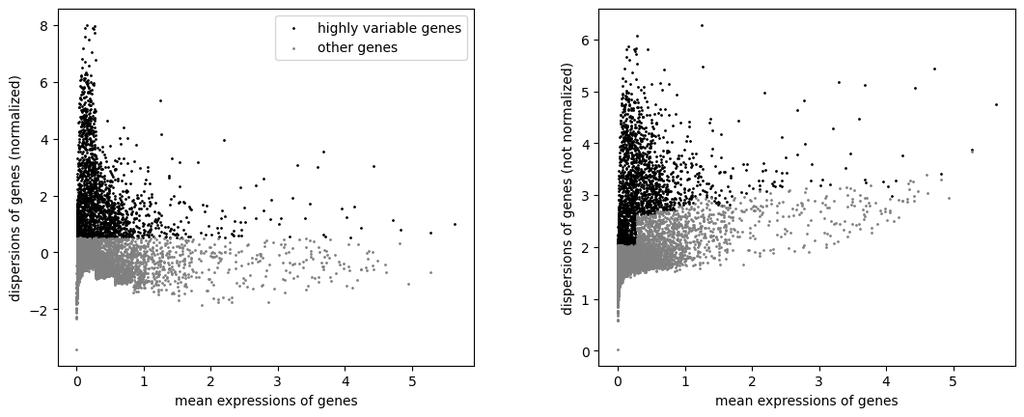

```python
# Save raw counts, then normalize/log1p into .X (required by LLM-scCurator)
adata.layers["counts"] = adata.X.copy()

# Normalize + log1p (standard)
sc.pp.normalize_total(adata, target_sum=1e4)
sc.pp.log1p(adata)

# HVG selection
sc.pp.highly_variable_genes(
    adata,
    n_top_genes=2000,
    flavor="seurat",
    subset=False,
)
sc.pl.highly_variable_genes(adata)
```

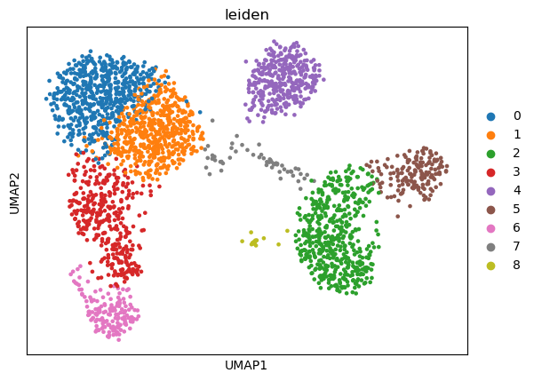

```python
# PCA/Neighbors/UMAP/Leiden using HVGs
sc.tl.pca(adata)
sc.pp.neighbors(adata)
sc.tl.umap(adata)
sc.tl.leiden(adata)
sc.pl.umap(adata, color=["leiden"])
```

## Run LLM-scCurator, noise masking and Gini-informed distillation

```python
# Curator Initialize
from llm_sc_curator.backends import OllamaBackend
backend = OllamaBackend()
curator = LLMscCurator(backend=backend)
curator.set_global_context(adata)
```

```python
# Choose a cluster (edit if you want a specific one)
cluster_name = sorted(adata.obs["leiden"].astype(str).unique())[0]
print(f"cluster_name = {cluster_name}")
```

```
cluster_name = 0
```

```python
# --- Standard DE: Target vs Rest ---
N_GENES = 50
TMP = "__tmp_binary__"

# --- Standard: DE (Target vs Rest) ---
adata.obs[TMP] = "Rest"
adata.obs.loc[adata.obs["leiden"].astype(str) == str(cluster_name), TMP] = "Target"

sc.tl.rank_genes_groups(
    adata,
    groupby=TMP,
    groups=["Target"],
    reference="Rest",
    method="wilcoxon",
    use_raw=False,
)

df_std = sc.get.rank_genes_groups_df(adata, group="Target")
genes_std = df_std["names"].head(N_GENES).tolist()

adata.obs.drop(columns=[TMP], inplace=True, errors="ignore")

# --- Curated: LLM-scCurator ---
genes_cur = curator.curate_features(
    adata,
    group_col="leiden",
    target_group=str(cluster_name),
    n_top=N_GENES,
    use_statistics=True,
)

print("genes_std len =", len(genes_std))
print("genes_cur len =", len(genes_cur))
```

```
genes_std len = 50
genes_cur len = 50
```

```python
# --- Readable output: lists + rescued/dropped + table ---
def _fmt_list(title, genes, n=10, bullet="•"):
    genes = [str(g) for g in (genes or [])]
    head = genes[:n]
    body = "\n".join([f"{bullet} {g}" for g in head]) if head else f"{bullet} (empty)"
    return f"{title} (top {len(genes)}, showing {min(n, len(genes))})\n{body}"

std = [str(g) for g in genes_std]
cur = [str(g) for g in genes_cur]

std_set = set(std)
cur_set = set(cur)

rescued = [g for g in cur if g not in std_set]
dropped = [g for g in std if g not in cur_set]
overlap = [g for g in cur if g in std_set]

print(f"\nGene list summary: std={len(std)} | curated={len(cur)} | shared={len(overlap)} | rescued={len(rescued)} | dropped={len(dropped)}\n")

print("🟦 " + _fmt_list("Standard genes", std, n=10))
print()
print("🟥 " + _fmt_list("Curated genes", cur, n=10))
print()
print("➕ " + _fmt_list("Rescued (curated-only)", rescued, n=10))
print()
print("➖ " + _fmt_list("Dropped (std-only)", dropped, n=10))

TOP = 15
def _pad(xs, n=TOP):
    xs = [str(x) for x in (xs or [])][:n]
    return xs + [""] * (n - len(xs))

df_view = pd.DataFrame({
    "🏆 rank ": list(range(1, TOP + 1)),
    "🟦 standard ": _pad(genes_std, TOP),
    "🟥 curated ":  _pad(genes_cur, TOP),
})

df_view.insert(0, "cluster", str(cluster_name))
df_view
```

```
Gene list summary: std=50 | curated=50 | shared=1 | rescued=49 | dropped=49

🟦 Standard genes (top 50, showing 10)
• RPL32
• RPS27
• RPS12
• RPS6
• RPS3A
• RPL31
• RPS25
• RPL9
• RPS15A
• RPS14

🟥 Curated genes (top 50, showing 10)
• CD3D
• CD3E
• SRSF5
• SELL
• LTB
• MAL
• HINT1
• GIMAP5
• TRAF3IP3
• CD3G

➕ Rescued (curated-only) (top 49, showing 10)
• CD3E
• SRSF5
• SELL
• LTB
• MAL
• HINT1
• GIMAP5
• TRAF3IP3
• CD3G
• LDLRAP1

➖ Dropped (std-only) (top 49, showing 10)
• RPL32
• RPS27
• RPS12
• RPS6
• RPS3A
• RPL31
• RPS25
• RPL9
• RPS15A
• RPS14
```

|  | cluster | 🏆 rank | 🟦 standard | 🟥 curated |
| --- | --- | --- | --- | --- |
| 0 | 0 | 1 | RPL32 | CD3D |
| 1 | 0 | 2 | RPS27 | CD3E |
| 2 | 0 | 3 | RPS12 | SRSF5 |
| 3 | 0 | 4 | RPS6 | SELL |
| 4 | 0 | 5 | RPS3A | LTB |
| 5 | 0 | 6 | RPL31 | MAL |
| 6 | 0 | 7 | RPS25 | HINT1 |
| 7 | 0 | 8 | RPL9 | GIMAP5 |
| 8 | 0 | 9 | RPS15A | TRAF3IP3 |
| 9 | 0 | 10 | RPS14 | CD3G |
| 10 | 0 | 11 | RPL13 | LDLRAP1 |
| 11 | 0 | 12 | RPLP2 | TRABD2A |
| 12 | 0 | 13 | RPS27A | FYB |
| 13 | 0 | 14 | RPL3 | CD2 |
| 14 | 0 | 15 | RPL30 | STK17A |

## Run LLM-scCurator hierarchical discovery (writes major_type / fine_type)

```python
# ============================================================
# Optional: automatic hierarchical annotation (coarse-to-fine)
# ============================================================

# This will add columns like adata.obs["major_type"] and adata.obs["fine_type"].
N_GENES = 50

import time
t0 = time.time()
adata_llm = curator.run_hierarchical_discovery(
    adata,
    n_top=N_GENES,
    batch_key=None, # set this if you want batch-aware behavior
)
t1 = time.time()

print(f"run_hierarchical_discovery() total: {t1 - t0:.1f} sec")
display(adata_llm.obs[["major_type","fine_type"]].head())
```

```
run_hierarchical_discovery() total: 453.1 sec
```

| index | major_type | fine_type |
| --- | --- | --- |
| AAACATACAACCAC-1 | CD8+ T cell (ISG-high) | CD8+ T cell (ISG-high) |
| AAACATTGAGCTAC-1 | Activated B cell (proliferating) | Activated B cell (proliferating) |
| AAACATTGATCAGC-1 | CD8+ T cell (ISG-high) | CD8+ T cell (ISG-high) |
| AAACCGTGCTTCCG-1 | Monocyte | Monocyte (ISG-high) |
| AAACCGTGTATGCG-1 | CD8+ T cell (ISG-high) | CD8+ T cell (ISG-high) |

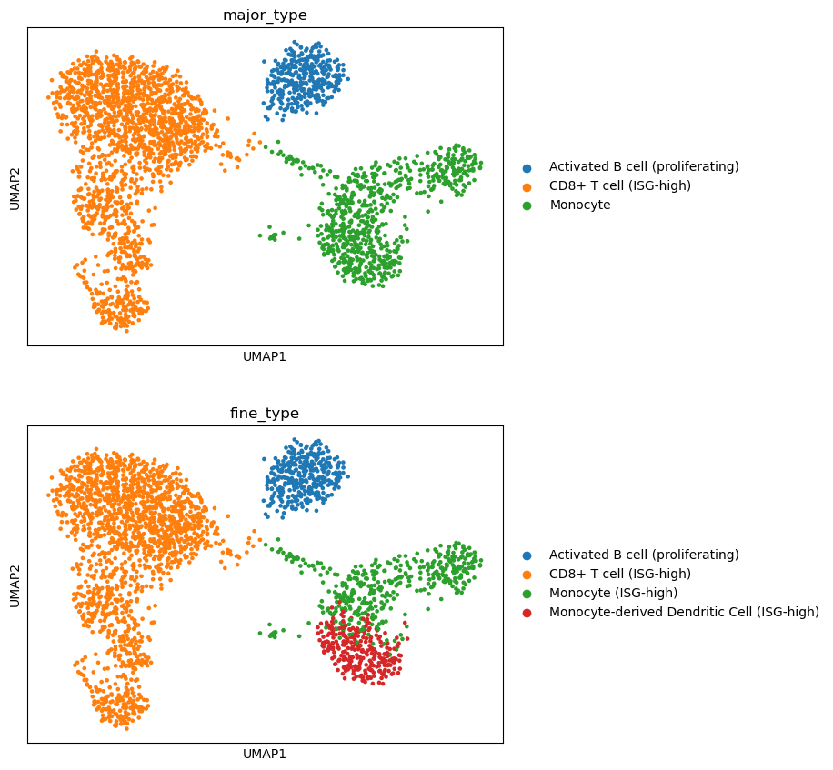

```python
# Plot only if they exist
cols_to_plot = [c for c in ["major_type", "fine_type"] if c in adata.obs.columns]
if cols_to_plot and "X_umap" in adata.obsm:
    sc.pl.umap(adata, color=cols_to_plot, ncols=1)
```

## Quick marker dotplots for sanity-checking labels

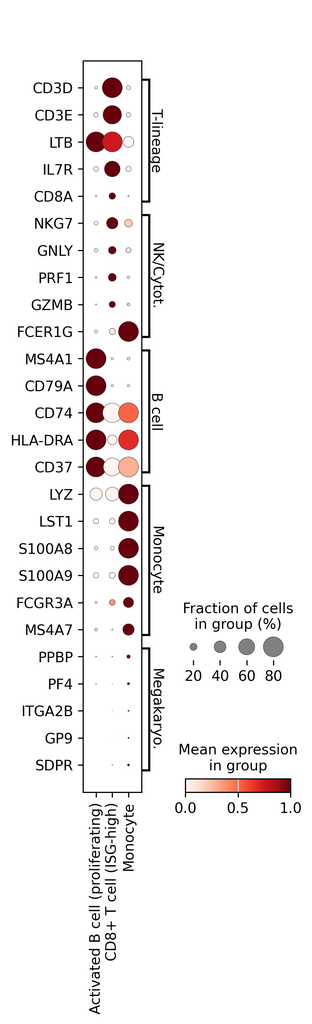

```python
sc.set_figure_params(dpi=140, fontsize=12)

# ---------- marker panels (canonical) ----------
MARKERS_MAJOR = {
    "T-lineage":       ["TRAC", "CD3D", "CD3E", "LTB", "IL7R", "CD8A"],
    "NK/Cytotoxic":    ["NKG7", "GNLY", "PRF1", "GZMB", "FCER1G"],
    "B cell":          ["MS4A1", "CD79A", "CD74", "HLA-DRA", "CD37"],
    "Monocyte":        ["LYZ", "LST1", "S100A8", "S100A9", "FCGR3A", "MS4A7"],
    "Megakaryocyte":   ["PPBP", "PF4", "ITGA2B", "GP9", "SDPR"],
}

# ---------- Utility: drop genes not present + dedupe across groups ----------
def filter_and_dedupe_markers(marker_dict, var_names):
    vset = set(map(str, var_names))
    used = set()
    out = {}
    for group, genes in marker_dict.items():
        cleaned = []
        for g in genes:
            g = str(g)
            if g not in vset:
                continue
            if g in used:
                continue
            cleaned.append(g)
            used.add(g)
        if cleaned:
            out[group] = cleaned
    return out

# Major type dotplot
markers = filter_and_dedupe_markers(MARKERS_MAJOR, adata.var_names)
sc.pl.dotplot(
    adata,
    markers,
    groupby="major_type",
    standard_scale="var",
    use_raw=False,
    swap_axes=True,
    dot_min=0.0,
    dot_max=0.8,
    show=True,
)
```

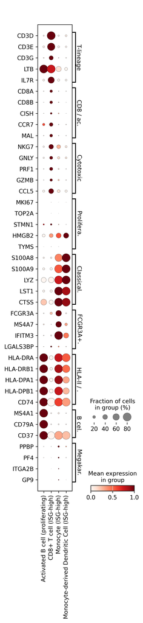

```python
MARKERS_FINE = {
    "T-lineage":         ["TRAC", "CD3D", "CD3E", "CD3G", "LTB", "IL7R"],
    "CD8 / activation":  ["CD8A", "CD8B", "CISH", "CCR7", "MAL"],
    "Cytotoxic":         ["NKG7", "GNLY", "PRF1", "GZMB", "CCL5"],
    "Proliferation":     ["MKI67", "TOP2A", "STMN1", "HMGB2", "TYMS"],
    "Classical mono":    ["S100A8", "S100A9", "LYZ", "LST1", "CTSS"],
    "FCGR3A+ mono":      ["FCGR3A", "MS4A7", "IFITM3", "LGALS3BP"],
    "HLA-II / APC":      ["HLA-DRA", "HLA-DRB1", "HLA-DPA1", "HLA-DPB1", "CD74"],
    "B cell":            ["MS4A1", "CD79A", "CD74", "CD37"],
    "Megakaryocyte":     ["PPBP", "PF4", "ITGA2B", "GP9"],
}


# ---------- Plot settings ----------
markers = filter_and_dedupe_markers(MARKERS_FINE, adata.var_names)
sc.pl.dotplot(
    adata,
    markers,
    groupby="fine_type",
    standard_scale="var",
    use_raw=False,
    swap_axes=True,
    dot_min=0.0,
    dot_max=0.8,
    show=True,
)
```

## Annotate existing clusters (v0.1.1+)

If you already have clusters (e.g., Seurat seurat_clusters, Leiden, etc.) and want to annotate each cluster once, then export a shareable table (CSV) and propagate labels to cells, use the utilities added in v0.1.1+.

```python
# CONFIG
cluster_col = "leiden"
out_csv = "cluster_curated_map.csv"
prefix = "Curated"
```

```python
clusters = sorted(adata.obs[cluster_col].astype(str).unique())
cluster_results = {}
genes_by_cluster = {}

for cl in clusters:
    genes = curator.curate_features(
        adata,
        group_col=cluster_col,
        target_group=str(cl),
    )

    genes_by_cluster[str(cl)] = genes or []

    if genes:
        cluster_results[str(cl)] = curator.annotate(genes)
    else:
        cluster_results[str(cl)] = {
            "cell_type": "NoGenes",
            "confidence": "Low",
            "reasoning": "Curated gene list empty",
        }
```

```python
# EXPORT TABLE
df_cluster = export_cluster_annotation_table(
    adata,
    cluster_col=cluster_col,
    cluster_results=cluster_results,
    genes_by_cluster=genes_by_cluster,
    prefix=prefix,
)
df_cluster.to_csv(out_csv, index=False)
print(f"Wrote {out_csv}")

df_cluster
```

```
Wrote cluster_curated_map.csv
```

|  | leiden | n_cells | Curated_CellType | Curated_Confidence | Curated_Reasoning | Curated_Genes |
| --- | --- | --- | --- | --- | --- | --- |
| 0 | 0 | 582 | CD8+ T cell (ISG-high) | High | Presence of CD3D, CD3E, CD8B and TRAF3IP3 indi... | CD3D;CD3E;SRSF5;SELL;LTB;MAL;HINT1;GIMAP5;TRAF... |
| 1 | 1 | 536 | CD4 Temra.EffMem T cell | High | Presence of CD3D, CD3E, GIMAP7, and IL32 indic... | LTB;IL32;CD3D;CD3E;GIMAP7;CD2;AQP3;HINT1;GIMAP... |
| 2 | 2 | 489 | Monocyte | High | Presence of CD68, S100A8, S100A9, and FCN1 ind... | LYZ;S100A9;S100A8;TYROBP;FCN1;CST3;LGALS2;S100... |
| 3 | 3 | 355 | CD8+ exhausted T cell (ISG-high) | High | Presence of GZMB, CD8A, and high expression of... | CCL5;NKG7;IL32;GZMA;CTSW;CST7;GZMK;CD3D;PTPRCA... |
| 4 | 4 | 348 | Activated B cell (proliferating) | High | The presence of CD74, HLA-DRA, and CD79A/B ind... | CD74;HLA-DRA;CD79A;CD79B;HLA-DPB1;MS4A1;HLA-DQ... |
| 5 | 5 | 162 | Monocyte | High | Presence of CD68, C1orf162, and S100A9 indicat... | LST1;FCER1G;AIF1;COTL1;FCGR3A;IFITM3;SAT1;CTSS... |
| 6 | 6 | 158 | NK cell (activated) | High | Presence of NKG7, GNLY, GZMB, and PRF1 indicat... | NKG7;GNLY;GZMB;CTSW;PRF1;CST7;GZMA;FGFBP2;CD24... |
| 7 | 7 | 54 | Monocyte | High | Presence of CD74, HLA-DRB1, and CST3 indicates... | HLA-DRB1;CD74;HLA-DRA;HLA-DPB1;HLA-DQB1;HLA-DQ... |
| 8 | 8 | 16 | Endothelial cell (proliferating) | Medium | The presence of PPBP, GPX1, and CD9 suggests a... | PPBP;GPX1;SDPR;PF4;NRGN;OAZ1;CCL5;GNG11;SPARC;... |

```python
# PER-CELL LABEL
apply_cluster_map_to_cells(
    adata,
    cluster_col=cluster_col,
    df_cluster=df_cluster,
    label_col=f"{prefix}_CellType",
    new_col=f"{prefix}_CellType",
)
```

```
AnnData object with n_obs × n_vars = 2700 × 13714
    obs: 'n_genes', 'leiden', 'leiden_coarse', 'major_type', 'fine_type', 'Curated_CellType'
    var: 'gene_ids', 'n_cells', 'highly_variable', 'means', 'dispersions', 'dispersions_norm'
    uns: 'log1p', 'hvg', 'pca', 'neighbors', 'umap', 'leiden', 'leiden_colors', 'rank_genes_groups', 'leiden_coarse', 'llm_reasoning', 'major_type_colors', 'fine_type_colors'
    obsm: 'X_pca', 'X_umap'
    varm: 'PCs'
    layers: 'counts'
    obsp: 'distances', 'connectivities'
```

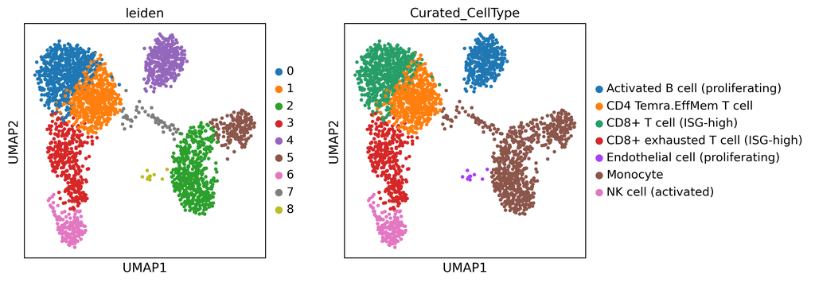

```python
sc.pl.umap(adata, color=["leiden", f"{prefix}_CellType"])
```

```python
# ---- OPTIONAL: LABEL HARMONIZATION ----
label_map = {
    # Example: Add according to your project
}

if label_map:
    adata = harmonize_labels(
        adata,
        col=f"{prefix}_CellType",
        mapping=label_map,
        new_col=f"{prefix}_CellType_harmonized",
        keep_raw=True,
    )
    out_csv2 = out_csv.replace(".csv", "_harmonized.csv")
    df_cluster2 = df_cluster.copy()
    df_cluster2[f"{prefix}_CellType"] = df_cluster2[f"{prefix}_CellType"].replace(label_map)
    df_cluster2.to_csv(out_csv2, index=False)
    print(f"Wrote {out_csv2}")

# ---- QUICK CHECK ----
print(df_cluster[[cluster_col, "n_cells", f"{prefix}_CellType", f"{prefix}_Confidence"]].head())
```

```
  leiden  n_cells                  Curated_CellType Curated_Confidence
0      0      582            CD8+ T cell (ISG-high)               High
1      1      536           CD4 Temra.EffMem T cell               High
2      2      489                          Monocyte               High
3      3      355  CD8+ exhausted T cell (ISG-high)               High
4      4      348  Activated B cell (proliferating)               High
```